# Predicting Carseat Sales Using Multiple Linear Regression

## 3.3 Pairwise Relationships

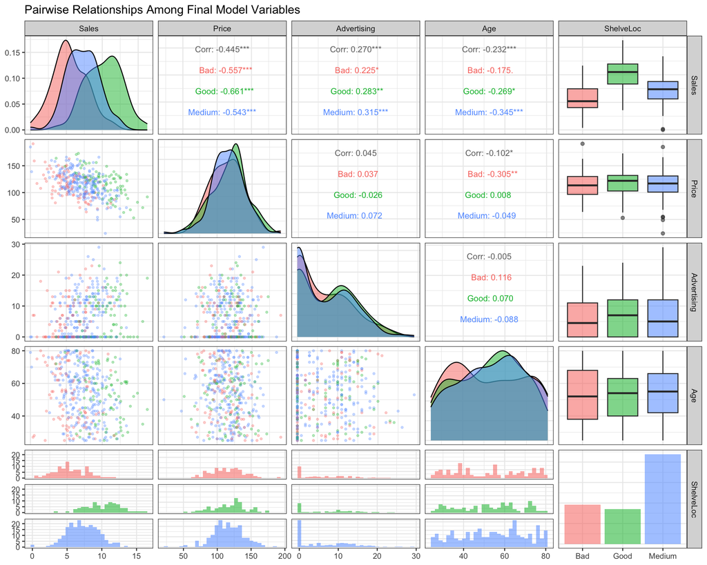

```r
Carseats %>%
  select(Sales, Price, Advertising, Age, ShelveLoc) %>%
  ggpairs(
    aes(color = ShelveLoc, alpha = 0.4),
    upper = list(continuous = wrap("cor", size = 3)),
    lower = list(continuous = wrap("points", alpha = 0.3, size = 0.8)),
    diag  = list(continuous = wrap("densityDiag", alpha = 0.5))
  ) +
  theme_bw(base_size = 10) +
  ggtitle("Pairwise Relationships Among Final Model Variables")
```

The pairwise plot confirms that `Price` has a clear negative relationship with `Sales` across all shelf locations, while `Advertising` and `Age` show moderate associations. Importantly, the predictors themselves show little correlation with each other, which is a good sign against multicollinearity.

# 4 Model Specification

## 4.1 Predictor Justification

The final model uses **four predictors**:

| Predictor | Type | Justification |
| --- | --- | --- |
| `Price` | Numeric | Strongest correlation with Sales (r = −0.44); highly significant |
| `ShelveLoc` | Categorical (3 levels) | Strongest categorical predictor (F = 92.23, p < 0.001) |
| `Advertising` | Numeric | Second strongest numeric predictor (r = 0.27); significant |
| `Age` | Numeric | Meaningful negative association (r = −0.23); significant |

`Urban`, `US`, `Income`, `CompPrice`, `Education`, and `Population` were excluded based on non-significant ANOVA results, near-zero correlations, or non-significance once other predictors are in the model.

## 4.2 Final Model Equation

$$\widehat{\text{Sales}} = 14.5287 -
0.0638 \cdot \text{Price} + 4.9472 \cdot \text{ShelveLocGood} + 2.0504
\cdot \text{ShelveLocMedium} + 0.1068 \cdot \text{Advertising} - 0.0482
\cdot \text{Age}$$

`ShelveLoc` uses **Bad** as the reference level. The coefficients for `ShelveLocGood` and `ShelveLocMedium` represent the difference in expected Sales relative to stores with Bad shelf placement, holding all other predictors constant.

# 5 Data Splitting

The dataset is split into **80% training** and **20% test** sets, stratified by `ShelveLoc` to ensure all three shelf location levels are proportionally represented in both partitions.

```r
set.seed(42)
carseats_split <- initial_split(Carseats, prop = 0.80, strata = ShelveLoc)
carseats_train <- training(carseats_split)
carseats_test  <- testing(carseats_split)

cat("Training observations:", nrow(carseats_train), "\n")
```

```
## Training observations: 319
```

```r
cat("Test observations:    ", nrow(carseats_test),  "\n")
```

```
## Test observations:     81
```